# US Craft Beer Analysis

Nathan Wall, Muthu Palanisamy, Nathan Lara

February 15, 2018

# Analysis of US Craft beers Alcohol by Volume (ABV) & Internation Bitterness Unit (IBU)

We will be analyzing data on 2410 US craft beers from 558 different breweries to identify various characteristics of the US craft beer industry. Spefically we will be focusing on a beers ABV and IBU and there geographic properties and relationships to one another.

### Reading & Manipulating Data from source

The data for this analysis is stored on GitHub in the following repository: https://github.com/nateewall/MSDS6306_CaseStudy1

We will be using R’s RCurl package to read this data directly from the web.

```r
#if you do not have the RCurl package then install
#install.packages("RCurl")
#Reference RCurl package to read from web
require(RCurl)
# Read Breweries dataset
breweriesURL <- 'https://raw.githubusercontent.com/nateewall/MSDS6306_CaseStudy1/master/Breweries.csv'
Breweries <-read.csv(text=getURL(breweriesURL), header=T)

# Read the Beers Dataset
beersURL <- 'https://raw.githubusercontent.com/nateewall/MSDS6306_CaseStudy1/master/Beers.csv'
Beers <-read.csv(text=getURL(beersURL), header=T)
```

### Exploring the data

Once the data is read into R data.frames from the web we will quickly review the format of the data to make sure all feilds were captured appropriately.

Breweries:

```r
# Review the data
str(Breweries)
```

```
## 'data.frame':    558 obs. of  4 variables:
##  $ Brew_ID: int  1 2 3 4 5 6 7 8 9 10 ...
##  $ Name   : Factor w/ 551 levels "10 Barrel Brewing Company",..: 355 12 266 319 201 136 227 477 59 491 ...
##  $ City   : Factor w/ 384 levels "Abingdon","Abita Springs",..: 228 200 122 299 300 62 91 48 152 136 ...
##  $ State  : Factor w/ 51 levels " AK"," AL"," AR",..: 24 18 20 5 5 41 6 23 23 23 ...
```

Our Breweries data.frame has 558 observations with 551 distinct breweries from 51 states and 384 different cities.

Below we will see how many breweries are located in each of the 51 states in our data:

```r
# How many breweries are present in each state?
BreweryStates <- summary(Breweries$State)
#Print in sorted order
sort(BreweryStates, decreasing = T)
```

```
##  CO  CA  MI  OR  TX  PA  MA  WA  IN  WI  NC  IL  NY  VA  FL  OH  MN  AZ
##  47  39  32  29  28  25  23  23  22  20  19  18  16  16  15  15  12  11
##  VT  ME  MO  MT  CT  AK  GA  MD  OK  IA  ID  LA  NE  RI  HI  KY  NM  SC
##  10   9   9   9   8   7   7   7   6   5   5   5   5   5   4   4   4   4
##  UT  WY  AL  KS  NH  NJ  TN  AR  DE  MS  NV  DC  ND  SD  WV
##   4   4   3   3   3   3   3   2   2   2   2   1   1   1   1
```

### Merge the data sets together to have the geography for each of the beer.

Below is the code used to merge the two data sets by Brewery ID and a quick review of top and the bottom of our new data set.

```r
mergedBeerBreweries<-merge(
  Breweries, Beers, by.x = "Brew_ID", by.y ="Brewery_id", all= TRUE
)

# Assign appropriate name
names(mergedBeerBreweries)[2]<-"BreweryName"
names(mergedBeerBreweries)[5]<-"BeerName"

#print the top 6 records
head(mergedBeerBreweries, 6)
```

```
##   Brew_ID        BreweryName        City State      BeerName Beer_ID   ABV
## 1       1 NorthGate Brewing  Minneapolis    MN       Pumpion    2689 0.060
## 2       1 NorthGate Brewing  Minneapolis    MN    Stronghold    2688 0.060
## 3       1 NorthGate Brewing  Minneapolis    MN   Parapet ESB    2687 0.056
## 4       1 NorthGate Brewing  Minneapolis    MN  Get Together    2692 0.045
## 5       1 NorthGate Brewing  Minneapolis    MN Maggie's Leap    2691 0.049
## 6       1 NorthGate Brewing  Minneapolis    MN    Wall's End    2690 0.048
##   IBU                               Style Ounces
## 1  38                         Pumpkin Ale     16
## 2  25                     American Porter     16
## 3  47 Extra Special / Strong Bitter (ESB)     16
## 4  50                        American IPA     16
## 5  26                  Milk / Sweet Stout     16
## 6  19                   English Brown Ale     16
```

```r
#print the bottom 6 records
tail(mergedBeerBreweries, 6)
```

```
##      Brew_ID                   BreweryName          City State
## 2405     556         Ukiah Brewing Company         Ukiah    CA
## 2406     557       Butternuts Beer and Ale Garrattsville    NY
## 2407     557       Butternuts Beer and Ale Garrattsville    NY
## 2408     557       Butternuts Beer and Ale Garrattsville    NY
## 2409     557       Butternuts Beer and Ale Garrattsville    NY
## 2410     558 Sleeping Lady Brewing Company     Anchorage    AK
##                       BeerName Beer_ID   ABV IBU                   Style
## 2405             Pilsner Ukiah      98 0.055  NA         German Pilsener
## 2406         Porkslap Pale Ale      49 0.043  NA American Pale Ale (APA)
## 2407           Snapperhead IPA      51 0.068  NA            American IPA
## 2408         Moo Thunder Stout      50 0.049  NA      Milk / Sweet Stout
## 2409  Heinnieweisse Weissebier      52 0.049  NA              Hefeweizen
## 2410 Urban Wilderness Pale Ale      30 0.049  NA        English Pale Ale
##      Ounces
## 2405     12
## 2406     12
## 2407     12
## 2408     12
## 2409     12
## 2410     12
```

Based on the output above we can see that the data appears to have successfully been merged. Although there are lots of NA’s in the for the IBU column so we will perform a count of all NA’s in our data.

```r
# There are multiple ways to get the NA's
# Can go with sapply..
sapply(mergedBeerBreweries, function(x) sum(is.na(x)))
```

```
##     Brew_ID BreweryName        City       State    BeerName     Beer_ID
##           0           0           0           0           0           0
##         ABV         IBU       Style      Ounces
##          62        1005           0           0
```

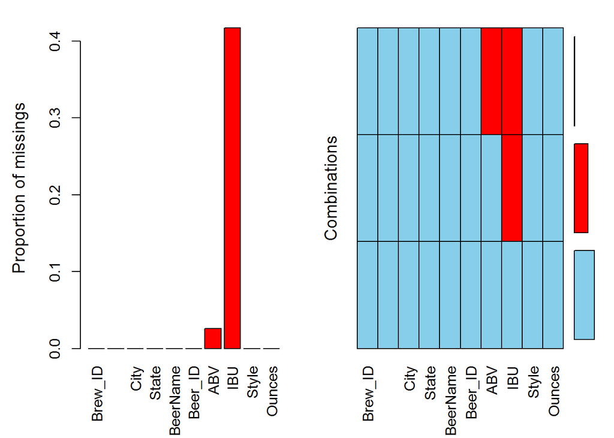

```r
require(VIM) #use the VIM package to visualize
aggr(mergedBeerBreweries)
```

It appears the most of the columns have 0 NA’s with the exception of 62 NA’s for ABV & 1005 NA’s for IBU. We are assuming this data was not available for the beers from this group.

### Analyzing the Beers ABV & IBU

First, we will begin by taking a look at the median alcohol content for each of the states to determine if there are any major differences.